# Transcriptomic Analysis - Host DESeq2

Maggie Sogin

2026-11-17

# Introduction

This notebook analyzes metatranscriptomic (RNA-seq) data from an *Aiptasia* bacterial inoculation experiment. *Aiptasia* were first treated with antibiotics to reduce their native microbiome, then inoculated with one of three bacterial symbionts to examine changes in host, algal symbiont, and bacterial gene expression.

*Still needed*: refine annotation categories at end of DEGs and look at unannoated ones for TrEMBL annotations

**Treatments:**

- **control/FASW** — no antibiotics, no inoculation (natural microbiome)
- **ABS** — antibiotics only (microbiome-depleted baseline)
- **ISOA/Labrenzia** — antibiotics + *Labrenzia aggregata* inoculation
- **ISOB/Ruegeria** — antibiotics + *Ruegeria mobilis* inoculation
- **ISOC/Vibrio** — antibiotics + *Vibrio alginolyticus* inoculation
- **ISOABC/multi** — antibiotics + all three bacteria combined

**Timepoints:** 1 day post-inoculation (1dpi) and 21 days post-inoculation (21dpi)

**Replicates:** 4 biological replicates per treatment per timepoint = **48 samples total**

**Previous pipeline:** Raw reads were processed with fastp (quality trimming) → SortMeRNA (rRNA removal) → HISAT2 (alignment to a combined reference genome containing *Aiptasia* host, *Symbiodiniaceae* symbiont, *Labrenzia*, *Ruegeria*, and *Vibrio*) → featureCounts (gene-level quantification).

**Biological questions:**

1. What are the general expression patterns across treatments and timepoints?
2. How does bacterial inoculation affect host immune gene expression?
3. Are there changes in sulfur cycling genes, particularly in *Labrenzia* and *Ruegeria*?

**Updated questions** 1. Is there a common host response to bacteria inoculation regardless of treatment? - compare ABS to each treatment at each timepoint

2. How does host expression change when inoculated with vibrio alone vs. in multi-species combinations? Hypotheses:
- Host gene expression is more similar with inoculations of beneficial microbes vs pathogen
- Inoculation of multispecies together causes differences in host gene expression
- Inoculation of pathogen results in DE expression of key genes involved in immune systems and the presence of other bacteria dampens that response (idea –> BMCs do not want to be targeted?)
3. Are there changes in host gene expression that work to recognizing BMCs and not pathogens?

# 1. Load Libraries & Define Constants

```r
library(readxl)
library(tidyverse)
library(DESeq2)
library(ggplot2)
library(pheatmap)
library(matrixStats)
library(ggrepel)
library(patchwork)
library(UpSetR)
library(stringr)
library(topGO)
library(vegan)
library(dplyr)
library("RColorBrewer")
library(scales)
```

```r
palette <- c(
  "FASW" = 'grey60',
  "ABS"     = 'black',
  "Labrenzia"    = '#A6CEE3',
  "Ruegeria"    = '#1F78B4',
  "Vibrio"    = '#B2DF8A',
  "multi"  = 'violet')
treatment_levels <- c(
  "control" = "FASW",
  "ABS" = "ABS",
  "ISOA" = "Labrenzia",
  "ISOB" = "Ruegeria",
  "ISOC" = "Vibrio",
  "ISOABC" = "multi")

path.out<-"../../output/transcriptomics_v3"
```

# 2. Load All Data Files

```r
#load data
load(file.path(path.out,'host_data.RData'))
ls()
```

```
## [1] "aip_annotate"     "colData"          "counts_aip"       "palette"
## [5] "path.out"         "treatment_levels"
```

# 3. DESeq2 Analysis — Host (*Aiptasia*)

Host differential expression analysis using DESeq2. DESeq2 models RNA-seq count data using a negative binomial distribution, accounts for library size differences between samples, and uses shrinkage to produce more reliable fold-change estimates.

The design should include three terms: timepoint, teratment and treatment:timepoint interaction

## 3.1 Create DESeq object, filter data and run LRT test

https://bioconductor.org/packages/devel/bioc/vignettes/DESeq2/inst/doc/DESeq2.html#countmat As per recommendations in Interactions section:

```r
dds_aip <- DESeqDataSetFromMatrix(
  countData = counts_aip,
  colData = colData,
  design = ~ timepoint*treatment)

cat(nrow(dds_aip), "genes before filtering\n")
```

```
## 29269 genes before filtering
```

```r
keep <- rowSums(counts(dds_aip) >= 10) >= 4
dds_aip <- dds_aip[keep, ]
cat(nrow(dds_aip), "genes after filtering\n")
```

```
## 27033 genes after filtering
```

```r
#removes genes that don't have at least 10 counts in at least 4 samples, this helps to reduced noise in analysis
```

## 3.2 Run DESeq analysis

want to look at differences in gene expression at each time-point across treatment groups

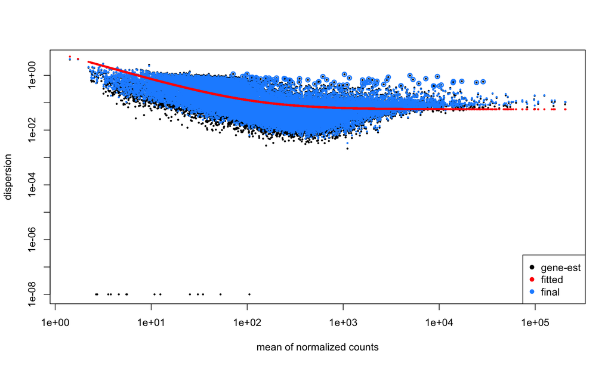

```r
ds<-DESeq(dds_aip)
plotDispEsts(ds)
```

```r
# Dispersion plot looks good: trend line decreases smoothly, gene-wise estimates converge (black dots)
```

## 3.3 Exploratory plots

### VST Transformation

```r
vsd_aip <- vst(dds_aip, blind = TRUE)
```

### PCA — All Samples

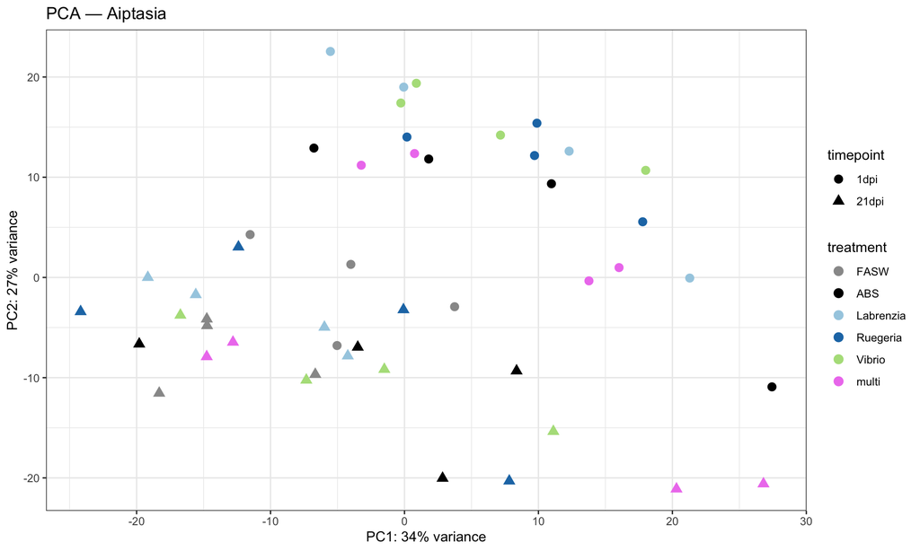

```r
pca_data <- plotPCA(vsd_aip, intgroup = c("treatment", "timepoint"), returnData = TRUE)
percent_var <- round(100 * attr(pca_data, "percentVar"))

p <- ggplot(pca_data, aes(x = PC1, y = PC2, color = treatment, shape = timepoint)) +
  geom_point(size = 3) +
  scale_color_manual(values = palette) +
  theme_bw() +
  labs(x = paste0("PC1: ", percent_var[1], "% variance"),
       y = paste0("PC2: ", percent_var[2], "% variance"),
       title = "PCA — Aiptasia")
p
```

```r
ggsave(file.path(path.out,"PCA_ALL_Samples.pdf"), p, width = 7, height = 5)
# Timepoint is the dominant source of variation, although controls at 1dpi cluster with all 21dpi, suggesting variation largely due to ABS influence
```

```r
# get VST matrix (samples as rows)
vsd_mat <- t(assay(vsd_aip))

# pull metadata
meta <- as.data.frame(colData(vsd_aip))

# run PERMANOVA
perm_res_global <- adonis2(vsd_mat ~ treatment*timepoint,
                    data = meta,
                    method = "euclidean",
                    permutations = 999,
                    by=NULL)
perm_res_global
```

```
## Permutation test for adonis under reduced model
## Permutation: free
## Number of permutations: 999
##
## adonis2(formula = vsd_mat ~ treatment * timepoint, data = meta, permutations = 999, method = "euclidean", by = NULL)
##          Df SumOfSqs      R2     F Pr(>F)
## Model    11    71284 0.33056 1.616  0.021 *
## Residual 36   144360 0.66944
## Total    47   215644 1.00000
## ---
## Signif. codes:  0 '***' 0.001 '**' 0.01 '*' 0.05 '.' 0.1 ' ' 1
```

```r
perm_res <- adonis2(vsd_mat ~ treatment*timepoint,
                    data = meta,
                    method = "euclidean",
                    permutations = 999,
                    by="terms")
perm_res
```

```
## Permutation test for adonis under reduced model
## Terms added sequentially (first to last)
## Permutation: free
## Number of permutations: 999
##
## adonis2(formula = vsd_mat ~ treatment * timepoint, data = meta, permutations = 999, method = "euclidean", by = "terms")
##                     Df SumOfSqs      R2      F Pr(>F)
## treatment            5    32270 0.14964 1.6095  0.058 .
## timepoint            1    21407 0.09927 5.3385  0.002 **
## treatment:timepoint  5    17607 0.08165 0.8781  0.584
## Residual            36   144360 0.66944
## Total               47   215644 1.00000
## ---
## Signif. codes:  0 '***' 0.001 '**' 0.01 '*' 0.05 '.' 0.1 ' ' 1
```

Significant effect of time but not treatment on expression profiles Suggests that expression differences are related to ABS exposure and not to microbial inoculations.

### PCA 1dpi

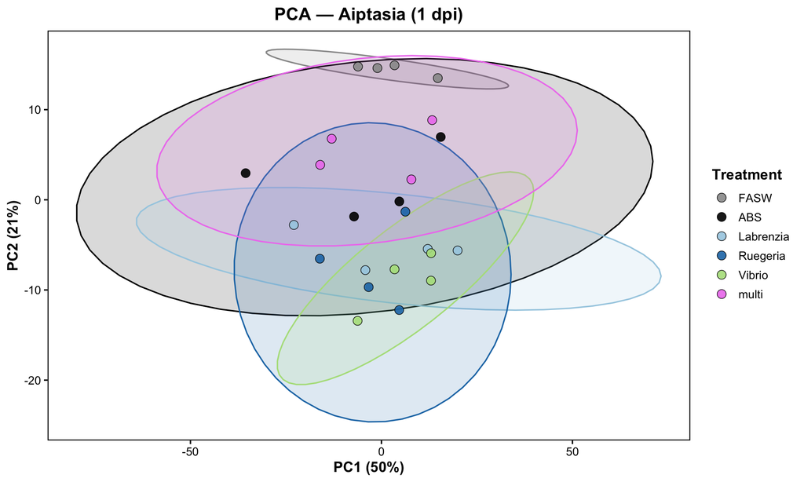

```r
vsd_1dpi <- vsd_aip[, vsd_aip$timepoint == "1dpi"]

pca_data <- plotPCA(vsd_1dpi, intgroup = "treatment", returnData = TRUE)
percent_var <- round(100 * attr(pca_data, "percentVar"))

p <- ggplot(pca_data, aes(x = PC1, y = PC2, color = treatment, fill = treatment)) +
  stat_ellipse(geom = "polygon", type = "t", level = 0.95,
               alpha = 0.15, linewidth = 0.6, show.legend = FALSE) +
  geom_point(size = 3.5, shape = 21, color = "black", stroke = 0.4, alpha = 0.9) +
  scale_color_manual(values = palette) +
  scale_fill_manual(values = palette) +
  theme_classic(base_size = 13) +
  theme(
    plot.title      = element_text(face = "bold", hjust = 0.5),
    axis.title      = element_text(face = "bold"),
    axis.text       = element_text(color = "black"),
    legend.title    = element_text(face = "bold"),
    panel.border    = element_rect(color = "black", fill = NA, linewidth = 0.8),
    axis.line       = element_blank()
  ) +
  labs(x = paste0("PC1 (", percent_var[1], "%)"),
       y = paste0("PC2 (", percent_var[2], "%)"),
       title = "PCA — Aiptasia (1 dpi)",
       fill = "Treatment") +
  guides(color = "none")

p
```

```r
ggsave(file.path(path.out, "pca_host_1dpi.pdf"), p, width = 7, height = 5)
```

```r
# get VST matrix (samples as rows)
vsd_mat_1dpi <- t(assay(vsd_1dpi))

# pull metadata
meta_1dpi <- as.data.frame(colData(vsd_1dpi))


# run PERMANOVA
perm_res <- adonis2(vsd_mat_1dpi ~ treatment+timepoint,
                    data = meta_1dpi,
                    method = "euclidean",
                    permutations = 999,
                    by="terms")
perm_res
```

```
## Permutation test for adonis under reduced model
## Terms added sequentially (first to last)
## Permutation: free
## Number of permutations: 999
##
## adonis2(formula = vsd_mat_1dpi ~ treatment + timepoint, data = meta_1dpi, permutations = 999, method = "euclidean", by = "terms")
##           Df SumOfSqs      R2      F Pr(>F)
## treatment  5    18378 0.22947 1.0721  0.367
## Residual  18    61711 0.77053
## Total     23    80088 1.00000
```

### PCA 21dpi

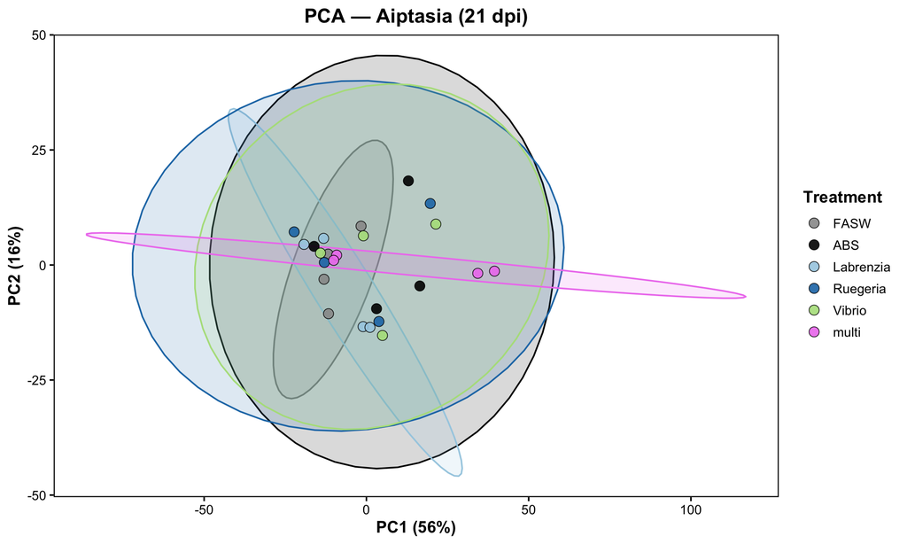

```r
vsd_21dpi <- vsd_aip[, vsd_aip$timepoint == "21dpi"]

pca_data <- plotPCA(vsd_21dpi, intgroup = "treatment", returnData = TRUE)
percent_var <- round(100 * attr(pca_data, "percentVar"))

p <- ggplot(pca_data, aes(x = PC1, y = PC2, color = treatment, fill = treatment)) +
  stat_ellipse(geom = "polygon", type = "t", level = 0.95,
               alpha = 0.15, linewidth = 0.6, show.legend = FALSE) +
  geom_point(size = 3.5, shape = 21, color = "black", stroke = 0.4, alpha = 0.9) +
  scale_color_manual(values = palette) +
  scale_fill_manual(values = palette) +
  theme_classic(base_size = 13) +
  theme(
    plot.title      = element_text(face = "bold", hjust = 0.5),
    axis.title      = element_text(face = "bold"),
    axis.text       = element_text(color = "black"),
    legend.title    = element_text(face = "bold"),
    panel.border    = element_rect(color = "black", fill = NA, linewidth = 0.8),
    axis.line       = element_blank()
  ) +
  labs(x = paste0("PC1 (", percent_var[1], "%)"),
       y = paste0("PC2 (", percent_var[2], "%)"),
       title = "PCA — Aiptasia (21 dpi)",
       fill = "Treatment") +
  guides(color = "none")

p
```

```r
ggsave(file.path(path.out, "pca_host_21dpi.pdf"), p, width = 7, height = 5)
```

```r
# get VST matrix (samples as rows)
vsd_mat_21dpi <- t(assay(vsd_21dpi))

# pull metadata
meta_21dpi <- as.data.frame(colData(vsd_21dpi))

# run PERMANOVA
perm_res <- adonis2(vsd_mat_21dpi ~ treatment+timepoint,
                    data = meta_21dpi,
                    method = "euclidean",
                    permutations = 999,
                    by="terms")
perm_res
```

```
## Permutation test for adonis under reduced model
## Terms added sequentially (first to last)
## Permutation: free
## Number of permutations: 999
##
## adonis2(formula = vsd_mat_21dpi ~ treatment + timepoint, data = meta_21dpi, permutations = 999, method = "euclidean", by = "terms")
##           Df SumOfSqs      R2     F Pr(>F)
## treatment  5    31498 0.27594 1.372  0.164
## Residual  18    82649 0.72406
## Total     23   114148 1.00000
```

### Sampel to Sample distance matrix

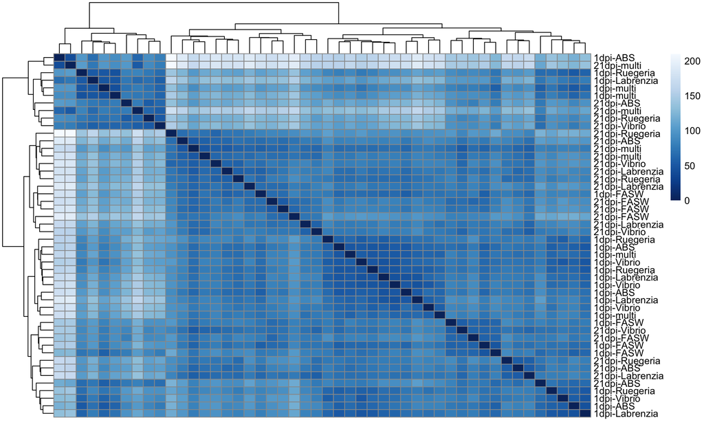

```r
sampleDists <- dist(vsd_mat)
sampleDistMatrix <- as.matrix(sampleDists)
rownames(sampleDistMatrix) <- paste(vsd_aip$timepoint, vsd_aip$treatment, sep="-")
colnames(sampleDistMatrix) <- NULL
colors <- colorRampPalette( rev(brewer.pal(9, "Blues")) )(255)
pheatmap(sampleDistMatrix,
         clustering_distance_rows=sampleDists,
         clustering_distance_cols=sampleDists,
         col=colors)
```

### Gene expression maps

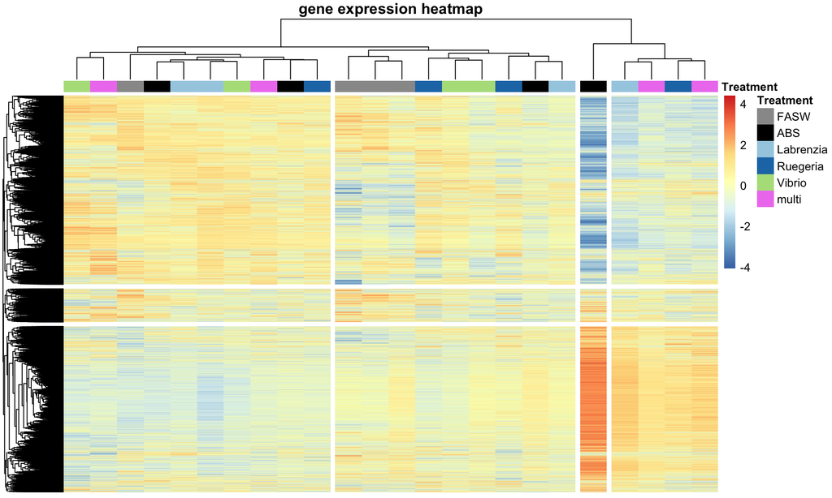

```r
timepoint_label="1dpi"

#get mat and transform to z-score
mat<-assay(vsd_aip[, vsd_aip$timepoint == timepoint_label])
mat_z<-t(scale(t(mat)))
mat<-mat[complete.cases(mat_z),]

title<-"gene expression heatmap"

# Column annotation
ann_col <- data.frame(
    Treatment = vsd_aip[, vsd_aip$timepoint == timepoint_label]$treatment,
    row.names = colnames(mat_z))

#row annotations
row_lab <- aip_annotate$protein_name[match(rownames(mat_z), aip_annotate$gene_id)]

p <- pheatmap(mat_z,
    annotation_col = ann_col,
    annotation_colors = list(
    Treatment = palette),
    show_rownames = F,
    show_colnames = F,
    labels_row = row_lab,
    fontsize_row = 5.5,
    cutree_rows = 3,
    cutree_cols = 4,
    main = title,
    silent = TRUE)
grid::grid.newpage(); grid::grid.draw(p$gtable)
```

## 3.4 Contrasts ### 1dpi

```r
tp<-'1dpi'
dds_aip_1dpi <- ds[, ds$timepoint == tp]
dds_aip_1dpi$timepoint <- droplevels(dds_aip_1dpi$timepoint)
design(dds_aip_1dpi) <- ~ treatment
dds_aip_1dpi$treatment <- relevel(dds_aip_1dpi$treatment, ref = "ABS")
dds_aip_1dpi <- DESeq(dds_aip_1dpi)  # re-run after releveling

resultsNames(dds_aip_1dpi)
```

```
## [1] "Intercept"                  "treatment_FASW_vs_ABS"
## [3] "treatment_Labrenzia_vs_ABS" "treatment_Ruegeria_vs_ABS"
## [5] "treatment_Vibrio_vs_ABS"    "treatment_multi_vs_ABS"
```

```r
#contrasts
res_aip_1dpi_control <- results(dds_aip_1dpi, name = "treatment_FASW_vs_ABS")
res_aip_1dpi_ISOA <- results(dds_aip_1dpi, name = "treatment_Labrenzia_vs_ABS")
res_aip_1dpi_ISOB <- results(dds_aip_1dpi, name = "treatment_Ruegeria_vs_ABS")
res_aip_1dpi_ISOC <- results(dds_aip_1dpi, name = "treatment_Vibrio_vs_ABS")
res_aip_1dpi_ISOABC <- results(dds_aip_1dpi, name = "treatment_multi_vs_ABS")

#contrasts with lfcShring
res_aip_1dpi_control_shrunk <- lfcShrink(dds_aip_1dpi, coef = "treatment_FASW_vs_ABS", res = res_aip_1dpi_control,type = "apeglm")
res_aip_1dpi_ISOA_shrunk <- lfcShrink(dds_aip_1dpi, coef = "treatment_Labrenzia_vs_ABS", res = res_aip_1dpi_ISOA,type = "apeglm")
res_aip_1dpi_ISOB_shrunk <- lfcShrink(dds_aip_1dpi, coef = "treatment_Ruegeria_vs_ABS", res = res_aip_1dpi_ISOB,type = "apeglm")
res_aip_1dpi_ISOC_shrunk <- lfcShrink(dds_aip_1dpi, coef = "treatment_Vibrio_vs_ABS", res = res_aip_1dpi_ISOC,type = "apeglm")
res_aip_1dpi_ISOABC_shrunk <- lfcShrink(dds_aip_1dpi, coef = "treatment_multi_vs_ABS", res = res_aip_1dpi_ISOABC,type = "apeglm")
```

### 21 dpi

```r
tp<-'21dpi'
dds_aip_21dpi <- ds[, ds$timepoint == tp]
dds_aip_21dpi$timepoint <- droplevels(dds_aip_21dpi$timepoint)
design(dds_aip_21dpi) <- ~ treatment
dds_aip_21dpi$treatment <- relevel(dds_aip_21dpi$treatment, ref = "ABS")
dds_aip_21dpi <- DESeq(dds_aip_21dpi)  # re-run after releveling

resultsNames(dds_aip_21dpi)
```

```
## [1] "Intercept"                  "treatment_FASW_vs_ABS"
## [3] "treatment_Labrenzia_vs_ABS" "treatment_Ruegeria_vs_ABS"
## [5] "treatment_Vibrio_vs_ABS"    "treatment_multi_vs_ABS"
```

```r
#contrasts
res_aip_21dpi_control <- results(dds_aip_21dpi, name = "treatment_FASW_vs_ABS")
res_aip_21dpi_ISOA <- results(dds_aip_21dpi, name = "treatment_Labrenzia_vs_ABS")
res_aip_21dpi_ISOB <- results(dds_aip_21dpi, name = "treatment_Ruegeria_vs_ABS")
res_aip_21dpi_ISOC <- results(dds_aip_21dpi, name = "treatment_Vibrio_vs_ABS")
res_aip_21dpi_ISOABC <- results(dds_aip_21dpi, name = "treatment_multi_vs_ABS")

#contrasts with lfcShring
res_aip_21dpi_control_shrunk <- lfcShrink(dds_aip_21dpi, coef = "treatment_FASW_vs_ABS", res = res_aip_21dpi_control,type = "apeglm")
res_aip_21dpi_ISOA_shrunk <- lfcShrink(dds_aip_21dpi, coef = "treatment_Labrenzia_vs_ABS", res = res_aip_21dpi_ISOA,type = "apeglm")
res_aip_21dpi_ISOB_shrunk <- lfcShrink(dds_aip_21dpi, coef = "treatment_Ruegeria_vs_ABS", res = res_aip_21dpi_ISOB,type = "apeglm")
res_aip_21dpi_ISOC_shrunk <- lfcShrink(dds_aip_21dpi, coef = "treatment_Vibrio_vs_ABS", res = res_aip_21dpi_ISOC,type = "apeglm")
res_aip_21dpi_ISOABC_shrunk <- lfcShrink(dds_aip_21dpi, coef = "treatment_multi_vs_ABS", res = res_aip_21dpi_ISOABC,type = "apeglm")
```

## 3.5 DEGs Tables with annotations

```r
# parse annotation table & prep for analysis
annot <- aip_annotate %>%
  mutate(
    # Short accession: UniProt ID for sp/tr, RefSeq ID for nr
    accession = case_when(
      str_detect(Hit.accession, "^(sp|tr)\\|") ~ str_split_i(Hit.accession, "\\|", 2),
      str_detect(Hit.accession, "^gi\\|")      ~ str_extract(Hit.accession, "(?<=ref\\|)[^|]+"),
      TRUE ~ NA_character_
    ),
    # UniProt entry name, e.g. FBX4_BOVIN
    entry_name = if_else(str_detect(Hit.accession, "^(sp|tr)\\|"),
                         str_split_i(Hit.accession, "\\|", 3), NA_character_),
    # Gene symbol from description, e.g. FBXO4
    gene_name = str_extract(Hit.description, "(?<=GN=)\\S+"),
    # Best single label: gene name > entry name > accession
    geneid = coalesce(gene_name, entry_name, accession)
  ) %>%
  dplyr::select(Protein_ID, gene_id, Source, geneid, accession, entry_name, gene_name,Hit.description, GO.terms)
head(annot)
```

```
##   Protein_ID      gene_id     Source         geneid      accession   entry_name
## 1   AIPGENE1 aip_AIPGENE1 Swiss-Prot        HI_1698         O05083  Y1698_HAEIN
## 2   AIPGENE2 aip_AIPGENE2         nr XP_005953050.1 XP_005953050.1         <NA>
## 3   AIPGENE3 aip_AIPGENE3     no_hit           <NA>           <NA>         <NA>
## 4   AIPGENE4 aip_AIPGENE4     no_hit           <NA>           <NA>         <NA>
## 5   AIPGENE5 aip_AIPGENE5     TrEMBL   H2ZWF0_LATCH         H2ZWF0 H2ZWF0_LATCH
## 6   AIPGENE6 aip_AIPGENE6     no_hit           <NA>           <NA>         <NA>
##   gene_name
## 1   HI_1698
## 2      <NA>
## 3      <NA>
## 4      <NA>
## 5      <NA>
## 6      <NA>
##                                                                                                                          Hit.description
## 1 Uncharacterized glycosyltransferase HI_1698 OS=Haemophilus influenzae (strain ATCC 51907 / DSM 11121 / KW20 / Rd) GN=HI_1698 PE=3 SV=1
## 2                                                                 PREDICTED: uncharacterized protein LOC102307237 [Haplochromis burtoni]
## 3
## 4
## 5                                                                    Uncharacterized protein (Fragment) OS=Latimeria chalumnae PE=4 SV=1
## 6
##                                                                                                                                                                                                                                                                                                          …
## 1                                                                                                                                                                                                                                                                         GO:0003674,GO:0003824,GO:000557…
## 2
## 3
## 4
## 5 GO:0003674,GO:0003676,GO:0003723,GO:0003824,GO:0003964,GO:0005488,GO:0006139,GO:0006259,GO:0006260,GO:0006278,GO:0006725,GO:0006807,GO:0008150,GO:0008152,GO:0009058,GO:0009059,GO:0009987,GO:0016740,GO:0016772,GO:0016779,GO:0034061,GO:0034641,GO:0034645,GO:0043170,GO:0044237,GO:0044238,GO:004424…
## 6
```

```r
#helpfunction to make DEG table
make_deg_table <- function(comp_data, comparison, timepoint, annotation_table,
                           padj_cutoff = 0.05) {
  as.data.frame(comp_data) %>%
    rownames_to_column(var = "row_id") %>%
    mutate(Protein_ID = sub("_gene", "", row_id)) %>%
    filter(!is.na(padj), padj < padj_cutoff) %>%
    left_join(annotation_table, by = "Protein_ID") %>%
    mutate(comp = comparison, timepoint = timepoint) %>%
    dplyr::select(Protein_ID, geneid, comp, timepoint,
                  baseMean, log2FoldChange, lfcSE, padj,
                  Source, accession, entry_name, gene_name,
                  Hit.description, GO.terms) %>%
    arrange(padj)
}
```

###3.5.1 tp = 1 dpi

```r
deg_set_fasw_v_abs_1dpi<-make_deg_table(res_aip_1dpi_control_shrunk,'FASW_vs_ABS','1dpi',annot)
deg_set_lab_v_abs_1dpi<-make_deg_table(res_aip_1dpi_ISOA_shrunk,'Labrenzia_vs_ABS','1dpi',annot)
deg_set_reu_v_abs_1dpi<-make_deg_table(res_aip_1dpi_ISOB_shrunk,'Reugeria_vs_ABS','1dpi',annot)
deg_set_vib_v_abs_1dpi<-make_deg_table(res_aip_1dpi_ISOC_shrunk,'Vibrio_vs_ABS','1dpi',annot)
deg_set_multi_v_abs_1dpi<-make_deg_table(res_aip_1dpi_ISOABC_shrunk,'Multi_vs_ABS','1dpi',annot)
```

###3.5.2 tp = 21dpi

```r
deg_set_fasw_v_abs_21dpi<-make_deg_table(res_aip_21dpi_control_shrunk,'FASW_vs_ABS','21dpi',annot)
deg_set_lab_v_abs_21dpi<-make_deg_table(res_aip_21dpi_ISOA_shrunk,'Labrenzia_vs_ABS','21dpi',annot)
deg_set_reu_v_abs_21dpi<-make_deg_table(res_aip_21dpi_ISOB_shrunk,'Reugeria_vs_ABS','21dpi',annot)
deg_set_vib_v_abs_21dpi<-make_deg_table(res_aip_21dpi_ISOC_shrunk,'Vibrio_vs_ABS','21dpi',annot)
deg_set_multi_v_abs_21dpi<-make_deg_table(res_aip_21dpi_ISOABC_shrunk,'Multi_vs_ABS','21dpi',annot)
```

###3.5.3 DEG tables for analyses

```r
#all DEGs
deg_names <- ls(pattern = "^deg_set")
deg_list <- mget(deg_names) #put dataframes into list
deg_list <- deg_list[!sapply(deg_list, is.null)]# Drop any NULLs
deg_list <- deg_list[sapply(deg_list, nrow) > 0] # Drop any with 0 rows
combined_deg <- bind_rows(deg_list, .id = "source")
combined_deg
```

```
##                        source   Protein_ID                geneid
## 1     deg_set_fasw_v_abs_1dpi  AIPGENE3833                  <NA>
## 2     deg_set_fasw_v_abs_1dpi AIPGENE12669                  <NA>
## 3     deg_set_fasw_v_abs_1dpi  AIPGENE3059                  <NA>
## 4     deg_set_fasw_v_abs_1dpi  AIPGENE3108                  <NA>
## 5     deg_set_fasw_v_abs_1dpi AIPGENE20289                   hex
## 6     deg_set_fasw_v_abs_1dpi AIPGENE14819                  DES1
## 7     deg_set_fasw_v_abs_1dpi AIPGENE11316             v1g243071
## 8     deg_set_fasw_v_abs_1dpi  AIPGENE3192                 Gpr98
## 9     deg_set_fasw_v_abs_1dpi AIPGENE18406                 Tret1
## 10    deg_set_fasw_v_abs_1dpi AIPGENE19708      AURANDRAFT_60931
## 11    deg_set_fasw_v_abs_1dpi AIPGENE13469                  vioA
## 12    deg_set_fasw_v_abs_1dpi AIPGENE22688                COL6A3
## 13    deg_set_fasw_v_abs_1dpi  AIPGENE3906               SLC6A11
## 14    deg_set_fasw_v_abs_1dpi AIPGENE26413      BRAFLDRAFT_67567
```

[output cut: 9915 more lines]

```r
#DEGs of interest across treatments, not FASW vs. ABS
degs_of_interest<-combined_deg %>%
                  filter(!comp=="FASW_vs_ABS")
dim(degs_of_interest)
```

```
## [1] 122  15
```

```r
length(unique(degs_of_interest$Protein_ID))
```

```
## [1] 99
```

```r
#degs in FASW vs. ABS
abs_fasw_degs <- combined_deg %>%
  filter(comp == "FASW_vs_ABS", padj < 0.05) %>%   #adjust padj cutoff if needed
  distinct(Protein_ID, timepoint)

#DEGs of interest, excluding all ABS and FASW DEGs
degs_of_interest.ex<-degs_of_interest %>%
  anti_join(abs_fasw_degs, by = c("Protein_ID", "timepoint"))
dim(degs_of_interest.ex)
```

```
## [1] 113  15
```

```r
#nr of unique proteins
length(unique(degs_of_interest.ex$Protein_ID))
```

```
## [1] 93
```

```r
#duplicated
dups<-degs_of_interest.ex[duplicated(degs_of_interest.ex$Protein_ID),] %>% arrange(Protein_ID)
dups
```

```
##                    source   Protein_ID    geneid            comp timepoint
## 1  deg_set_reu_v_abs_1dpi  AIPGENE1150      <NA> Reugeria_vs_ABS      1dpi
## 2  deg_set_vib_v_abs_1dpi  AIPGENE1150      <NA>   Vibrio_vs_ABS      1dpi
## 3  deg_set_reu_v_abs_1dpi AIPGENE18440     trp-1 Reugeria_vs_ABS      1dpi
## 4  deg_set_vib_v_abs_1dpi AIPGENE18440     trp-1   Vibrio_vs_ABS      1dpi
## 5  deg_set_vib_v_abs_1dpi AIPGENE18575     TRPC6   Vibrio_vs_ABS      1dpi
## 6  deg_set_reu_v_abs_1dpi AIPGENE18806 v1g218586 Reugeria_vs_ABS      1dpi
## 7  deg_set_vib_v_abs_1dpi AIPGENE18806 v1g218586   Vibrio_vs_ABS      1dpi
## 8  deg_set_reu_v_abs_1dpi AIPGENE19595      Fat3 Reugeria_vs_ABS      1dpi
## 9  deg_set_vib_v_abs_1dpi AIPGENE19595      Fat3   Vibrio_vs_ABS      1dpi
## 10 deg_set_reu_v_abs_1dpi AIPGENE19620 v1g242265 Reugeria_vs_ABS      1dpi
## 11 deg_set_vib_v_abs_1dpi AIPGENE19620 v1g242265   Vibrio_vs_ABS      1dpi
## 12 deg_set_vib_v_abs_1dpi AIPGENE19621 v1g211848   Vibrio_vs_ABS      1dpi
## 13 deg_set_vib_v_abs_1dpi  AIPGENE2015      <NA>   Vibrio_vs_ABS      1dpi
## 14 deg_set_reu_v_abs_1dpi AIPGENE24471     TTC28 Reugeria_vs_ABS      1dpi
```

[output cut: 90 more lines]

```r
dups$geneid
```

```
##  [1] NA          NA          "trp-1"     "trp-1"     "TRPC6"     "v1g218586"
##  [7] "v1g218586" "Fat3"      "Fat3"      "v1g242265" "v1g242265" "v1g211848"
## [13] NA          "TTC28"     "TTC28"     "nlrc5"     "SLC38A6"   "CDCP2"
## [19] "PLA2G4A"   "PLA2G4A"
```

```r
length(unique(dups$Protein_ID))
```

```
## [1] 13
```

```r
degs_of_interest.ex.1dpi<-degs_of_interest.ex %>% filter(timepoint=='1dpi') %>% arrange(Protein_ID)
length(unique(degs_of_interest.ex.1dpi$Protein_ID))
```

```
## [1] 81
```

###3.5.4 Annotations classifications of degs of interest

```r
#save table
write.csv(degs_of_interest.ex,file.path(path.out,'genes_of_interest.csv'))
```

```r
#set gene categories & assign
category_keywords<-list(
  "Adhesion" = c('Fat3','Nos7524_1372','CDCP2'),
  "Cell cycle" = c('RAB36','ssx2ip-a','TTC28'),
  "Sensory/neuronal" = c('SYT1','Chrna3','BB4'),
  "DNA repair" = c('DPOM_ASCIM','wrn'),
  "Immunity" = c('Fam26f','nlrc5','PRPX_HORVU', 'CPAMD8',"WP_011192704.1","OIT3"),
  "Ion channel" = c('SLC38A6'),
  "Oxylipin signaling" = c('trp-1','TRPC6'),
  "Metabolism" =c("CYP3A24","hyuA","ca2"),
  "Oxidative stress"=c("TP53I3","Hao1","CYBB","mocos"),
  "Sulfur metabolism"=c("TST"),
  "Lipid metabolism" =c("hsd17b12","PLA2G4A"),
  "Signaling" = c("SCOP1","Plch2","PRKX","Vwde"),
  "Transcription regulation" = c('Elk1','ZNF510','ANKRD12','KLF8','NKX1-1'),
  "Transport"=c('CUBN'),
  "Transposable element" = c('LIN1_NYCCO','POL','pol',"X-element"),
  "Growth regulation" = c("RERG","fgfr1a","Ptchd3","HMCN1"),
  "Signaling/defense" = c("Flt3","MIB1")
)

#1 turn list into look up table
keyword_df <- stack(category_keywords) %>%
  transmute(key = toupper(values),          # case-insensitive matching
            category = as.character(ind)) %>%
  distinct()
keyword_df
```

```
##               key                 category
## 1            FAT3                 Adhesion
## 2    NOS7524_1372                 Adhesion
## 3           CDCP2                 Adhesion
## 4           RAB36               Cell cycle
## 5        SSX2IP-A               Cell cycle
## 6           TTC28               Cell cycle
## 7            SYT1         Sensory/neuronal
## 8          CHRNA3         Sensory/neuronal
## 9             BB4         Sensory/neuronal
## 10     DPOM_ASCIM               DNA repair
## 11            WRN               DNA repair
## 12         FAM26F                 Immunity
## 13          NLRC5                 Immunity
## 14     PRPX_HORVU                 Immunity
```

[output cut: 35 more lines]

```r
# 2. Assign categories (exact match on gene_name, then entry_name, then geneid)
lookup <- function(x) keyword_df$category[match(toupper(x), keyword_df$key)]

deg <- degs_of_interest.ex %>%
  mutate(category = coalesce(lookup(gene_name),
                             lookup(entry_name),
                             lookup(geneid),
                             "Unassigned"))

# 3. Check the results
table(deg$category)
```

```
##
##                 Adhesion               Cell cycle               DNA repair
##                        6                        5                        2
##        Growth regulation                 Immunity              Ion channel
##                        4                        8                        2
##         Lipid metabolism               Metabolism         Oxidative stress
##                        4                        2                        3
##       Oxylipin signaling         Sensory/neuronal                Signaling
##                        5                        3                        4
##        Signaling/defense        Sulfur metabolism Transcription regulation
##                        2                        1                        5
##                Transport     Transposable element               Unassigned
##                        1                        4                       52
```

```r
#things not matching
setdiff(keyword_df$key,
        toupper(c(deg$gene_name, deg$entry_name, deg$geneid)))
```

```
## [1] "CYP3A24"   "TP53I3"    "X-ELEMENT"
```

```r
cat_base <- c(
  "Adhesion"                 = "#1F77B4",  # blue
  "Cell cycle"               = "#FF7F0E",  # orange
  "Sensory/neuronal"         = "#9467BD",  # purple
  "DNA repair"               = "#8C564B",  # brown
  "Immunity"                 = "#D62728",  # red
  "Signaling/defense"        = "#FF9896",  # salmon (between immunity + signaling)
  "Ion channel"              = "#17BECF",  # cyan
  "Oxylipin signaling"       = "#BCBD22",  # olive
  "Metabolism"               = "#2CA02C",  # green
  "Lipid metabolism"         = "#98DF8A",  # light green
  "Sulfur metabolism"        = "#637939",  # dark moss green
  "Oxidative stress"         = "#7B4173",  # plum
  "Signaling"                = "#E377C2",  # pink
  "Growth regulation"        = "#AEC7E8",  # light blue
  "Transcription regulation" = "#393B79",  # navy
  "Transport"                = "#525252",  # dark grey
  "Transposable element"     = "#E6AB02",  # gold
  "Unknown"               = "grey90"
)
```

###3.5.5 Summary of DEG table

```r
deg_summary<-combined_deg %>% group_by(comp, timepoint) %>%
  summarize(nr_DEGs=length(Protein_ID), up=sum(log2FoldChange>1),down=sum(log2FoldChange<1))
deg_summary<-deg_summary %>% arrange(timepoint,comp)
deg_summary
```

```
## # A tibble: 9 × 5
## # Groups:   comp [5]
##   comp             timepoint nr_DEGs    up  down
##   <chr>            <chr>       <int> <int> <int>
## 1 FASW_vs_ABS      1dpi          626    85   541
## 2 Labrenzia_vs_ABS 1dpi           12     1    11
## 3 Multi_vs_ABS     1dpi            3     0     3
## 4 Reugeria_vs_ABS  1dpi           16     0    16
## 5 Vibrio_vs_ABS    1dpi           72     2    70
## 6 FASW_vs_ABS      21dpi         906    75   831
## 7 Labrenzia_vs_ABS 21dpi           6     3     3
## 8 Reugeria_vs_ABS  21dpi           6     0     6
## 9 Vibrio_vs_ABS    21dpi           7     0     7
```

```r
write.csv(deg_summary,file.path(path.out,'summary_DEGs.csv'))
```

## 3.6 Visualization

###3.6.1 Compare nr of DEGs across groups between base (ABS) and treatment conditions #### ABS vs. FASW

```r
#subset to only have FASW vs ABS
df_filtered_control<-combined_deg %>% filter(Protein_ID %in% abs_fasw_degs$Protein_ID) %>% filter(comp=="FASW_vs_ABS")
table(df_filtered_control$comp)
```

```
##
## FASW_vs_ABS
##        1532
```

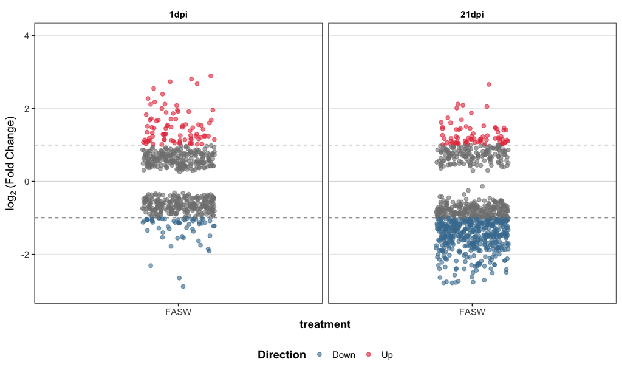

```r
# set up data for plotting
df <- df_filtered_control %>%
  separate(comp, into = c('treatment','base'), sep = "_vs_") %>%
  mutate(direction = case_when(
    log2FoldChange > 1  ~ 'up',
    log2FoldChange < -1 ~ 'down',
    TRUE                ~ 'no change'
  ))


#plot
ggplot(df, aes(x = treatment, y = log2FoldChange, color = direction)) +
  geom_hline(yintercept = c(-1, 1), linetype = 'dashed', color = 'gray60', linewidth = 0.4) +
  geom_hline(yintercept = 0, linetype = 'solid', color = 'gray85', linewidth = 0.3) +
  geom_jitter(height = 0, width = 0.15, alpha = 0.6, size = 1.8) +
  facet_grid(. ~ timepoint) +
  scale_color_manual(
    name = "Direction",
    values = c("up" = "#E63946",    # red
               "down" = "#457B9D",  # blue
               "NC" = "gray70"),
    labels = c("up" = "Up", "down" = "Down", "NC" = "No change")
  ) +
  labs(
    y = expression(log[2]~"(Fold Change)")
  ) +
  theme_bw(base_size = 13) +
  theme(
    axis.title = element_text(face = "bold"),
    strip.background = element_rect(fill = "white", color = NA),
    strip.text = element_text(color = "black", face = "bold"),
    panel.grid.minor = element_blank(),
    panel.grid.major.x = element_blank(),
    legend.position = "bottom",
    legend.title = element_text(face = "bold")
  ) + ylim(c(-3,4))
```

```r
ggsave(file.path(path.out,'deg_geneplot_control.svg'),height = 6, width=4)
```

#### ABSs vs. Treatment

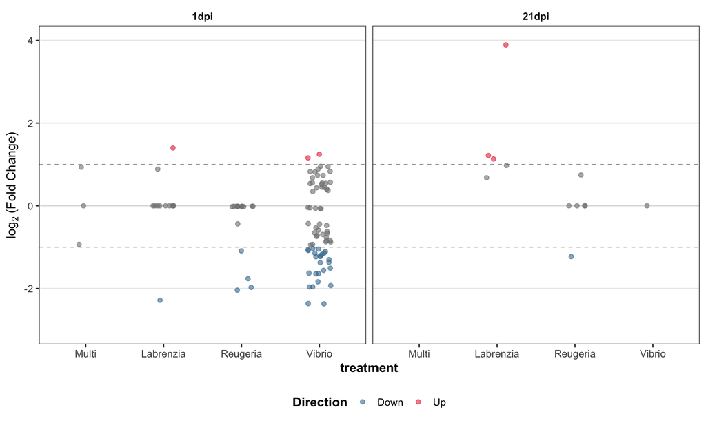

```r
df <- deg %>%
  separate(comp, into = c('treatment','base'), sep = "_vs_") %>%
  mutate(direction = case_when(
    log2FoldChange > 1  ~ 'up',
    log2FoldChange < -1 ~ 'down',
    TRUE                ~ 'no change'
  ))

df <- df %>%
  mutate(treatment = factor(treatment,
    levels = c("FASW",
               "Multi",
               "Labrenzia",
               "Reugeria",
               "Vibrio")))

#plot
ggplot(df, aes(x = treatment, y = log2FoldChange, color = direction)) +
  geom_hline(yintercept = c(-1, 1), linetype = 'dashed', color = 'gray60', linewidth = 0.4) +
  geom_hline(yintercept = 0, linetype = 'solid', color = 'gray85', linewidth = 0.3) +
  geom_jitter(height = 0, width = 0.15, alpha = 0.6, size = 1.8) +
  facet_grid(. ~ timepoint) +
  scale_color_manual(
    name = "Direction",
    values = c("up" = "#E63946",    # red
               "down" = "#457B9D",  # blue
               "NC" = "gray70"),
    labels = c("up" = "Up", "down" = "Down", "NC" = "No change")
  ) +
  labs(
    y = expression(log[2]~"(Fold Change)")
  ) +
  theme_bw(base_size = 13) +
  theme(
    axis.title = element_text(face = "bold"),
    strip.background = element_rect(fill = "white", color = NA),
    strip.text = element_text(color = "black", face = "bold"),
    panel.grid.minor = element_blank(),
    panel.grid.major.x = element_blank(),
    legend.position = "bottom",
    legend.title = element_text(face = "bold")
  ) + ylim(c(-3,4))
```

```r
ggsave(file.path(path.out,'deg_geneplot_trt.svg'),height = 6, width=6)
```

### 3.6.2 Heatmaps of DEGs

- Plot DEGs from each treatment (Labrenzia, Reugeria, Vibrio and Mult) excluding those in ABS vs FASW for all comparisons
- Filter genes with padj < 0.05
- We are not plotting DEGs bewteen ASW and FASW as these genes dominate expression differences in system

#### 1 dpi

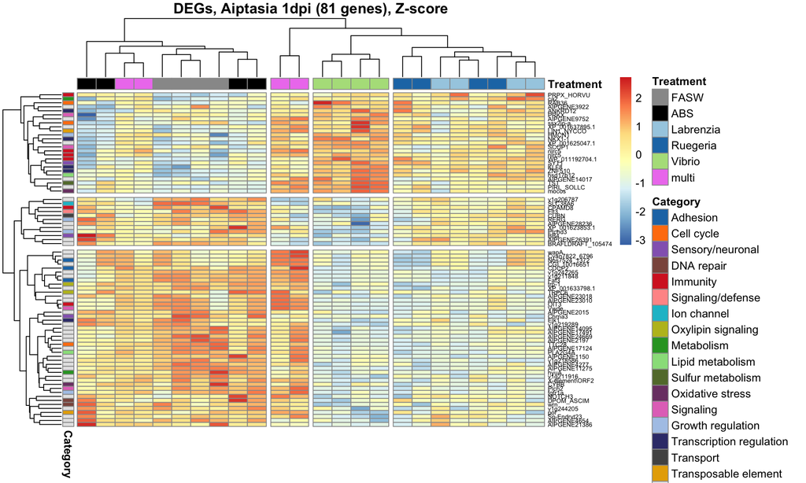

```r
timepoint_label <- "1dpi"
vsd <- vsd_aip

## ---- DEGs for this timepoint ----
deg.tp <- deg %>%
  dplyr::filter(timepoint == timepoint_label) %>%
  dplyr::mutate(row_id = paste0(Protein_ID, "_gene"))

sig_genes <- unique(deg.tp$row_id)

## ---- matrix + z-score ----
vsd_tp  <- vsd[, vsd$timepoint == timepoint_label]
mat     <- assay(vsd_tp)[rownames(vsd_tp) %in% sig_genes, ]
mat_z   <- t(scale(t(mat)))
mat_z   <- mat_z[complete.cases(mat_z), ]    # drop zero-variance rows

message(timepoint_label, ": ", length(sig_genes), " unique DEGs, ",
        sum(sig_genes %in% rownames(vsd_tp)), " found in vsd, ",
        nrow(mat_z), " plotted")

## ---- one row per gene for labels + categories ----
gene_info <- deg.tp %>%
  dplyr::distinct(row_id, .keep_all = TRUE)

row_lab <- gene_info$geneid[match(rownames(mat_z), gene_info$row_id)]
row_lab <- ifelse(is.na(row_lab) | row_lab == "",
                  sub("_gene$", "", rownames(mat_z)), row_lab)

row_categories <- gene_info$category[match(rownames(mat_z), gene_info$row_id)]
row_categories[is.na(row_categories) | row_categories == "Unknown"] <- "Unassigned"

## ---- annotations ----
cat_colors <- c(cat_base, "Unassigned" = "grey90")

ann_row <- data.frame(
  Category  = factor(row_categories,
                     levels = intersect(names(cat_colors), row_categories)),
  row.names = rownames(mat_z)
)

ann_col <- data.frame(
  Treatment = vsd_tp$treatment,
  row.names = colnames(mat_z)
)

## ---- heatmap ----
p_heat_1dpi <- pheatmap(mat_z,
  annotation_col    = ann_col,
  annotation_row    = ann_row,
  annotation_colors = list(
    Treatment = palette,
    Category  = cat_colors[levels(ann_row$Category)]   # name must match column
  ),
  show_rownames = TRUE,
  show_colnames = FALSE,
  labels_row    = row_lab,
  fontsize_row  = 5.5,
  cutree_rows   = 3,
  cutree_cols   = 4,
  main = paste0("DEGs, Aiptasia ", timepoint_label,
                " (", nrow(mat_z), " genes), Z-score"),
  silent = TRUE)

grid::grid.newpage(); grid::grid.draw(p_heat_1dpi$gtable)
```

```r
pdf(file.path(path.out, "annotated_heatmap_1dpi.pdf"), width = 8, height = 8)
grid::grid.draw(p_heat_1dpi$gtable)
dev.off()
```

#### 21 dpi

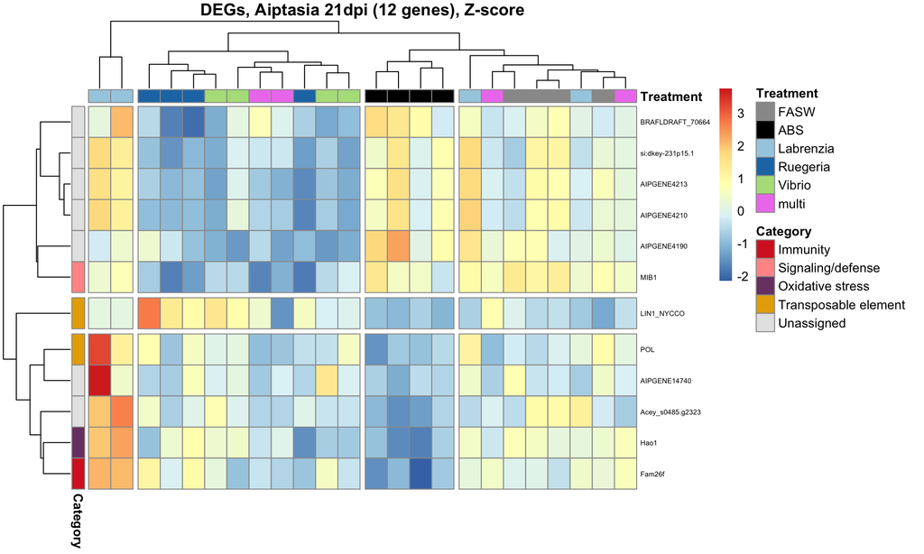

```r
timepoint_label <- "21dpi"
vsd <- vsd_aip

## ---- DEGs for this timepoint ----
deg.tp <- deg %>%
  dplyr::filter(timepoint == timepoint_label) %>%
  dplyr::mutate(row_id = paste0(Protein_ID, "_gene"))

sig_genes <- unique(deg.tp$row_id)

## ---- matrix + z-score ----
vsd_tp  <- vsd[, vsd$timepoint == timepoint_label]
mat     <- assay(vsd_tp)[rownames(vsd_tp) %in% sig_genes, ]
mat_z   <- t(scale(t(mat)))
mat_z   <- mat_z[complete.cases(mat_z), ]    # drop zero-variance rows

message(timepoint_label, ": ", length(sig_genes), " unique DEGs, ",
        sum(sig_genes %in% rownames(vsd_tp)), " found in vsd, ",
        nrow(mat_z), " plotted")

## ---- one row per gene for labels + categories ----
gene_info <- deg.tp %>%
  dplyr::distinct(row_id, .keep_all = TRUE)

row_lab <- gene_info$geneid[match(rownames(mat_z), gene_info$row_id)]
row_lab <- ifelse(is.na(row_lab) | row_lab == "",
                  sub("_gene$", "", rownames(mat_z)), row_lab)

row_categories <- gene_info$category[match(rownames(mat_z), gene_info$row_id)]
row_categories[is.na(row_categories) | row_categories == "Unknown"] <- "Unassigned"

## ---- annotations ----
cat_colors <- c(cat_base, "Unassigned" = "grey90")

ann_row <- data.frame(
  Category  = factor(row_categories,
                     levels = intersect(names(cat_colors), row_categories)),
  row.names = rownames(mat_z)
)

ann_col <- data.frame(
  Treatment = vsd_tp$treatment,
  row.names = colnames(mat_z)
)

## ---- heatmap ----
p_heat_1dpi <- pheatmap(mat_z,
  annotation_col    = ann_col,
  annotation_row    = ann_row,
  annotation_colors = list(
    Treatment = palette,
    Category  = cat_colors[levels(ann_row$Category)]   # name must match column
  ),
  show_rownames = TRUE,
  show_colnames = FALSE,
  labels_row    = row_lab,
  fontsize_row  = 5.5,
  cutree_rows   = 3,
  cutree_cols   = 4,
  main = paste0("DEGs, Aiptasia ", timepoint_label,
                " (", nrow(mat_z), " genes), Z-score"),
  silent = TRUE)

grid::grid.newpage(); grid::grid.draw(p_heat_1dpi$gtable)
```

```r
pdf(file.path(path.out, "annotated_heatmap_21dpi.pdf"), width = 8, height = 8)
grid::grid.draw(p_heat_1dpi$gtable)
dev.off()
```

###3.6.4 Gene expression rel to ABS

```r
# Get count data

#get counts
ds_sf<- estimateSizeFactors(ds)
norm_counts <- counts(ds_sf, normalized = TRUE)

#subset genes that have abs(log2foldchange >1)
deg.lcfc2<-deg %>% filter(abs(log2FoldChange) > 1)
```

```r
#get all DEGs of interest regardless of L2FC and subset count data
deg_ids <- deg %>% pull(Protein_ID) %>% unique() #93 genes in total
norm_sub <- norm_counts[rownames(norm_counts) %in% paste0(deg_ids,"_gene"), , drop = FALSE] #subsets count data here
dim(norm_sub);length(deg_ids)
```

```
## [1] 93 48
```

```
## [1] 93
```

```r
#get metadata
sample_meta <- as.data.frame(colData(ds_sf)) %>%
  mutate(sample = rownames(colData(ds_sf))) %>%
  dplyr::select(sample, treatment, timepoint)

#get means and se for each gene
expr_df <- as.data.frame(norm_sub) %>%
  rownames_to_column("Protein_ID") %>%
  pivot_longer(-Protein_ID, names_to = "sample", values_to = "norm_expr") %>%
  left_join(sample_meta, by = "sample") %>%
  group_by(Protein_ID, treatment, timepoint) %>%
  summarize(
    mean_avg = mean(norm_expr),
    se       = sd(norm_expr) / sqrt(n()),
    sample_size = n(),
    .groups = "drop"
  )
expr_df
```

```
## # A tibble: 1,116 × 6
##    Protein_ID        treatment timepoint mean_avg    se sample_size
##    <chr>             <fct>     <fct>        <dbl> <dbl>       <int>
##  1 AIPGENE10795_gene FASW      1dpi         1100. 321.            4
##  2 AIPGENE10795_gene FASW      21dpi        1230. 120.            4
##  3 AIPGENE10795_gene ABS       1dpi          869. 105.            4
##  4 AIPGENE10795_gene ABS       21dpi         593.  19.5           4
##  5 AIPGENE10795_gene Labrenzia 1dpi          439.  26.3           4
##  6 AIPGENE10795_gene Labrenzia 21dpi         901. 158.            4
##  7 AIPGENE10795_gene Ruegeria  1dpi          340.  26.4           4
##  8 AIPGENE10795_gene Ruegeria  21dpi         711.  81.2           4
##  9 AIPGENE10795_gene Vibrio    1dpi          507.  78.0           4
## 10 AIPGENE10795_gene Vibrio    21dpi         934. 160.            4
## # ℹ 1,106 more rows
```

```r
# pull ABS mean per gene x timepoint as the baseline
abs_means <- expr_df %>%
  filter(treatment == "ABS") %>%
  dplyr::select(Protein_ID, timepoint, abs_mean = mean_avg)

# compute relative mean + relative SE
expr_rel_df <- expr_df %>%
  left_join(abs_means, by = c("Protein_ID", "timepoint")) %>%
  mutate(
    rel_mean = mean_avg / abs_mean,
    rel_se   = se / abs_mean
  )

# check for zero/near-zero ABS baselines -- these will produce Inf/NaN
expr_rel_df %>% filter(is.infinite(rel_mean) | is.nan(rel_mean))
```

```
## # A tibble: 0 × 9
## # ℹ 9 variables: Protein_ID <chr>, treatment <fct>, timepoint <fct>,
## #   mean_avg <dbl>, se <dbl>, sample_size <int>, abs_mean <dbl>,
## #   rel_mean <dbl>, rel_se <dbl>
```

```r
expr_rel_df
```

```
## # A tibble: 1,116 × 9
##    Protein_ID   treatment timepoint mean_avg    se sample_size abs_mean rel_mean
##    <chr>        <fct>     <fct>        <dbl> <dbl>       <int>    <dbl>    <dbl>
##  1 AIPGENE1079… FASW      1dpi         1100. 321.            4     869.    1.27
##  2 AIPGENE1079… FASW      21dpi        1230. 120.            4     593.    2.07
##  3 AIPGENE1079… ABS       1dpi          869. 105.            4     869.    1
##  4 AIPGENE1079… ABS       21dpi         593.  19.5           4     593.    1
##  5 AIPGENE1079… Labrenzia 1dpi          439.  26.3           4     869.    0.505
##  6 AIPGENE1079… Labrenzia 21dpi         901. 158.            4     593.    1.52
##  7 AIPGENE1079… Ruegeria  1dpi          340.  26.4           4     869.    0.392
##  8 AIPGENE1079… Ruegeria  21dpi         711.  81.2           4     593.    1.20
##  9 AIPGENE1079… Vibrio    1dpi          507.  78.0           4     869.    0.583
## 10 AIPGENE1079… Vibrio    21dpi         934. 160.            4     593.    1.57
## # ℹ 1,106 more rows
## # ℹ 1 more variable: rel_se <dbl>
```

```r
# add gene categories
gene_labels <- deg %>%
  dplyr::select(geneid, category, Protein_ID) %>%
  distinct(geneid, .keep_all = TRUE) %>%
  mutate(Protein_ID = paste0(Protein_ID,"_gene"))

expr_rel_plot <- expr_rel_df %>%
  left_join(gene_labels, by = "Protein_ID") %>%
  mutate(treatment = factor(treatment, levels = c("ABS", setdiff(unique(treatment), "ABS"))))  %>%
  mutate(gene_label  = if_else(is.na(geneid), Protein_ID, geneid))
```

Plot below for each timepoint

```r
#refine the plot

## 2. Shades within each category: light -> base -> dark (skipping pure white/black)
shade_ramp <- function(base, n) {
  colorRampPalette(c("white", base, "black"))(n + 4)[3:(n + 2)]
}

expr_rel_plot <- expr_rel_plot %>%
  mutate(treatment = factor(treatment,
                             levels = c("ABS", "FASW", "multi", "Labrenzia", "Ruegeria", "Vibrio")))

gene_pal <- expr_rel_plot %>%
  distinct(category, geneid) %>%
  mutate(category = factor(category, levels = names(cat_base))) %>%
  arrange(category, geneid) %>%
  group_by(category) %>%
  mutate(color = shade_ramp(cat_base[as.character(category[1])], n()),
         shape = rep(c(16, 17, 15, 18, 8, 4, 3, 0, 1, 2, 5, 6), length.out = n())) %>%
  ungroup()

gene_colors <- setNames(gene_pal$color, gene_pal$geneid)
gene_shapes <- setNames(gene_pal$shape, gene_pal$geneid)
```

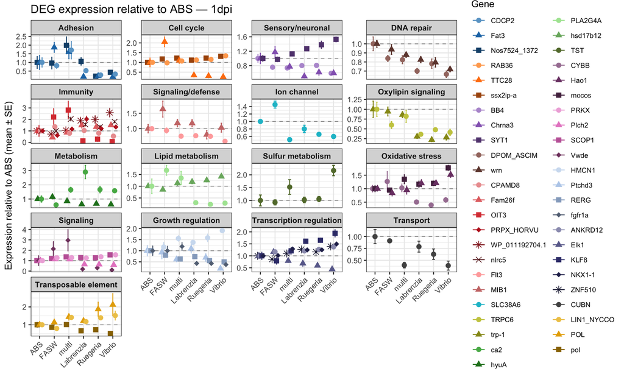

```r
## 3. Plot
library(ggnewscale)

tp<-"1dpi"

plot_df <- expr_rel_plot %>%
  mutate(category = factor(category, levels = names(cat_base)))

dodge <- position_dodge(width = 0.5)
cats  <- as.character(unique(gene_pal$category))   # categories present, in keyword order

p_rel_1 <- ggplot(plot_df  %>% filter(timepoint == tp) %>% filter(!category=='NA'), #removes NA category
                  aes(x = treatment, y = rel_mean, group = Protein_ID,
                      color = geneid, shape = geneid)) +
  geom_hline(yintercept = 1, linetype = "dashed", color = "grey60", linewidth = 0.4) +
  geom_errorbar(aes(ymin = rel_mean - rel_se, ymax = rel_mean + rel_se),
                width = 0.2, linewidth = 0.5, position = dodge) +
  geom_point(size = 2.5, position = dodge) +
  scale_color_manual(values = gene_colors, breaks = gene_pal$geneid, name = "Gene") +
  scale_shape_manual(values = gene_shapes, breaks = gene_pal$geneid, name = "Gene") +
  facet_wrap(~ factor(category, levels = names(cat_base)), scales = "free_y", ncol = 4) +
  labs(x = NULL, y = "Expression relative to ABS (mean \u00b1 SE)",
       title = paste("DEG expression relative to ABS \u2014", tp)) +
  theme_bw(base_size = 11) +
  theme(strip.text = element_text(face = "bold", size = 9),
        axis.text.x = element_text(angle = 45, hjust = 1),
        legend.position = "right",
        legend.text = element_text(size = 8)) +
  guides(color = guide_legend(ncol = 2))

p_rel_1
```

```r
ggsave(file.path(path.out,'DEG_cat_expression_plots_1dpi.svg'),height = 8, width=10)
```

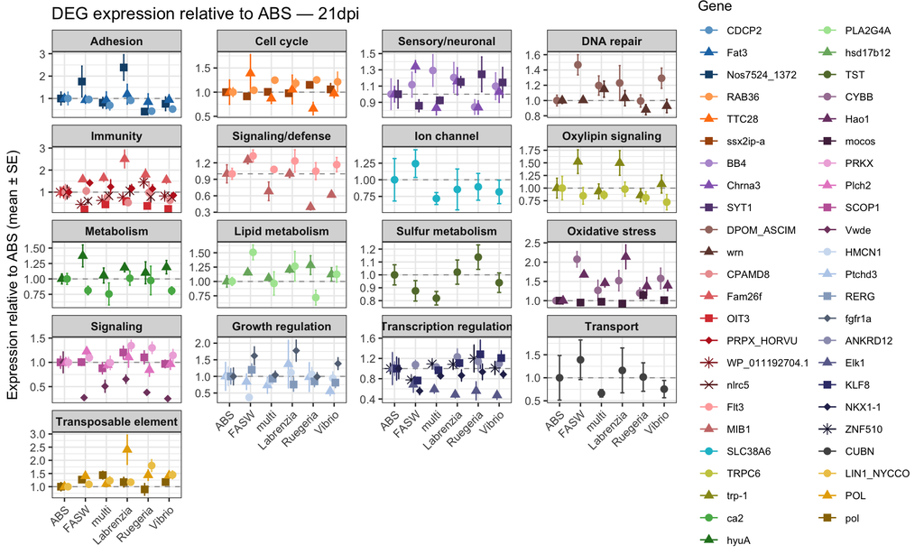

```r
##  Plot
tp<-"21dpi"

p_rel_21 <- ggplot(plot_df  %>% filter(timepoint == tp) %>% filter(!category=='NA'), #removes NA category
                  aes(x = treatment, y = rel_mean, group = Protein_ID,
                      color = geneid, shape = geneid)) +
  geom_hline(yintercept = 1, linetype = "dashed", color = "grey60", linewidth = 0.4) +
  geom_errorbar(aes(ymin = rel_mean - rel_se, ymax = rel_mean + rel_se),
                width = 0.2, linewidth = 0.5, position = dodge) +
  geom_point(size = 2.5, position = dodge) +
  scale_color_manual(values = gene_colors, breaks = gene_pal$geneid, name = "Gene") +
  scale_shape_manual(values = gene_shapes, breaks = gene_pal$geneid, name = "Gene") +
  facet_wrap(~ factor(category, levels = names(cat_base)), scales = "free_y", ncol = 4) +
  labs(x = NULL, y = "Expression relative to ABS (mean \u00b1 SE)",
       title = paste("DEG expression relative to ABS \u2014", tp)) +
  theme_bw(base_size = 11) +
  theme(strip.text = element_text(face = "bold", size = 9),
        axis.text.x = element_text(angle = 45, hjust = 1),
        legend.position = "right",
        legend.text = element_text(size = 8)) +
  guides(color = guide_legend(ncol = 2))

p_rel_21
```

```r
ggsave(file.path(path.out,'DEG_cat_expression_plots_21dpi.svg'),height = 8, width=10)
```